# ALGORITMA SELF ORGANIZING MAP

10. Untuk mengetahui objek yang masuk didalam lingkaran maka menggunakan syntax seperti berikut.

```r
som.wines$grid$pts
```

```
##         x         y
##  [1,] 1.5 0.8660254
##  [2,] 2.5 0.8660254
##  [3,] 3.5 0.8660254
##  [4,] 4.5 0.8660254
##  [5,] 5.5 0.8660254
##  [6,] 1.0 1.7320508
##  [7,] 2.0 1.7320508
##  [8,] 3.0 1.7320508
##  [9,] 4.0 1.7320508
## [10,] 5.0 1.7320508
## [11,] 1.5 2.5980762
## [12,] 2.5 2.5980762
## [13,] 3.5 2.5980762
## [14,] 4.5 2.5980762
## [15,] 5.5 2.5980762
## [16,] 1.0 3.4641016
## [17,] 2.0 3.4641016
## [18,] 3.0 3.4641016
## [19,] 4.0 3.4641016
## [20,] 5.0 3.4641016
## [21,] 1.5 4.3301270
## [22,] 2.5 4.3301270
## [23,] 3.5 4.3301270
## [24,] 4.5 4.3301270
## [25,] 5.5 4.3301270
```

Berdasarkan hasil output diatas dapat diketahui bahwa pada lingkaran pertama sumbu x bernilai 1.5 dan sumbu y bernilai 0.8660254 , pada lingkaran kedua sumbu x bernilai 2.5 dan sumbu y bernilai 0.8660254 dan seterusnya.

11. Untuk melihat letak nomer objek berapa yang masuk dalam lingkaran maka digunakan syntax seperti berikut.

```r
som.wines$unit.classif
```

```
##   [1] 15  4  5  3  5 15 10 15 15  5 14 14  5  5  4  4  4  5 10 10  9  9  9  9  3
##  [26]  9 14  9 15  4  4  9  4  9  9  9  9 14 10 10 20 10 20 15 10 10 15  4  5 15
##  [51]  4  5  4 10  4 10  4  5 12 18 18 12  6 17  8  6 11 18 13 17  2 17  3  2 12
##  [76] 12 17 13  1 11  7 16 22  2  7 16 16 21 16 21 21 21  7  7 13  8  6  6  1 11
## [101] 11  7 11 11 21 11 21 11  2  1  7 21 16 16 16 11  7 22 11  2  3 22  1  1  7
## [126]  7 21 16 22 19 19 19 19 18 18 23 23 24 23 23 19 23 22 19 19 24 24 24 25 25
## [151] 25 25 24 18 24 24 23 25 25 24 23 23 19 24 24 25 24 25 25 19 24 24 24 24 25
## [176] 25 24
```

12. Kemudian melihat plot keseluruhan som.wines dengan syntax seperti berikut

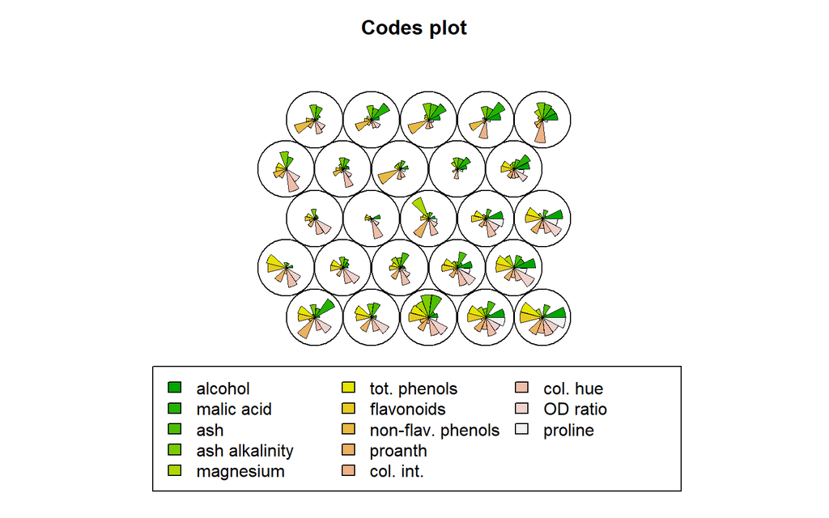

```r
plot(som.wines)
```

13. Selanjutnya melihat hasil pengelompokkan dari beberapa objek didalam masing-masing lingkaran dengan syntax seperti berikut.

```r
som.wines$codes[[1]]
```

```
##        alcohol malic acid         ash ash alkalinity   magnesium tot. phenols
## V1  -0.8146549  1.4987826 -0.49733361     0.40946953 -0.49003464    0.8814707
## V2  -0.8173438 -0.7266767  0.54471756     0.51699267 -0.43428287    0.8964554
## V3  -0.2954982 -0.2507016  2.04494075     1.80661801  1.81930384    1.0533648
## V4   0.9277002 -0.4881635  0.81775042    -0.15273103  0.80731070    0.9245165
## V5   1.4518024 -0.5170215  0.15858314    -1.19259067  0.49559004    1.6087048
## V6  -0.5985369 -0.9741057 -1.33344095    -0.61347136 -1.02789873    1.2752072
## V7  -0.8187998 -0.2720238 -0.50293875     0.14092352 -0.42467852    0.2149897
## V8  -0.8568940 -0.6124619  0.65104093     0.03700124  0.87975469   -0.2670318
## V9   0.4263026 -0.3432096  0.81139441    -0.50589179  0.13954130    0.4232998
## V10  1.2440709  0.2217815  0.16211751    -1.03665460  1.13282831    1.0727952
## V11 -0.9872231 -0.6220013 -1.54500911    -0.05571536 -0.91953461   -0.3186569
## V12 -0.3566687 -1.0072203 -2.30473933    -1.29355570 -0.59619824   -0.5810252
## V13 -0.6455091 -0.8856882 -1.08233382    -0.64597028  2.70752199   -0.5565979
## V14  0.7146374 -0.6073255 -0.43377339    -0.93380674 -0.31102442    0.1626149
## V15  1.0579352 -0.5745124 -0.59993280    -1.41067656 -0.08581570    0.7876076
## V16 -1.4444869 -0.8440764  0.09951054     1.09337961 -1.07338088   -0.1167125
## V17 -0.6823814 -0.4656071 -0.20875247     0.22810376 -0.07986587   -0.8993177
## V18 -0.4364561 -0.7456952 -0.62096004    -0.48603537 -0.12192583   -0.6461575
## V19 -0.2305454  0.6334103 -0.19785718     0.20528825  0.27982323   -1.4215682
## V20  0.4901806  0.9945890 -0.39759559    -0.38710855 -0.09261745    0.2313714
## V21 -1.0221179 -0.3257299  0.30648890     0.73482754 -0.88434419   -1.0252167
## V22 -0.4769148  1.2263222 -0.03963899     0.60840075 -0.80788405   -0.7007388
## V23 -0.0110950  1.1543307  0.77196772     0.92873451 -0.08291432   -0.8096292
## V24  0.4448711  1.3932869  0.07710061     0.46663541 -0.60549732   -0.9535486
## V25  0.4431448  0.5709117  0.76076921     1.05184057  0.78896019   -0.7293448
##      flavonoids non-flav. phenols     proanth   col. int.    col. hue
## V1   0.74276540       -0.23155772  1.60346212 -1.00940408  0.06083793
## V2   0.63337819       -0.93016270  0.68334240 -0.77888828  0.15515728
## V3   1.22849418        0.11626589  0.59142759 -0.34218450  0.66547824
## V4   0.99860130       -0.37257982  0.70788692  0.50004155  0.71950665
## V5   1.60681529       -0.48453669  1.07161845  1.02011903  0.68162408
## V6   1.01940844       -0.91125438  0.63924630 -0.37783052  0.77072649
## V7   0.26939953       -0.57936918 -0.11269280 -1.01238008  0.34086281
## V8  -0.02438804       -0.72790255  0.27062147 -0.63007895  0.53380891
## V9   0.61987725       -0.46002054  0.06559077 -0.35187795  0.62314612
## V10  1.01355590       -0.92088381  0.44230029  0.17419151  0.03711236
## V11 -0.17643970       -0.31771871 -0.13003843 -1.00149499  0.39309306
## V12 -0.56027769       -0.53781162 -1.11944768 -0.70113354  0.87368934
## V13 -0.33803085       -0.65358396  1.30899204 -0.78395976  0.50492871
```

[output cut: 23 more lines]

```
## V11  0.7067611 -0.74792007
## V12 -0.5029404 -0.77104380
## V13 -0.3275099  0.11784002
## V14  0.2911354  1.43681091
## V15  1.0247332  1.01967843
## V16  0.3128715 -0.86395292
## V17 -0.3083140 -0.72310584
## V18 -1.3604321 -0.34019261
## V19 -1.3205785 -0.23753341
## V20  0.2744949  0.30235908
## V21 -0.1033860 -0.76807455
## V22 -0.3332715 -0.84656510
## V23 -1.0030211 -0.36096708
## V24 -1.3496892 -0.41071568
## V25 -1.4465601 -0.38683608
```

14. Melakukan pengelompokkan berdasarkan nilai codes menggunakan cluster hierarki dengan syntax seperti berikut.

```r
dist(som.wines$codes[[1]])
```

```
##           V1       V2       V3       V4       V5       V6       V7       V8
## V2  2.778211
## V3  4.531094 3.433975
## V4  4.615181 3.497220 3.415945
## V5  5.394422 4.625742 4.967813 1.852069
## V6  3.291401 2.516755 5.315841 4.237178 4.562143
## V7  2.651289 1.792948 4.371855 4.234886 5.278624 2.289121
## V8  3.659623 2.262113 3.472555 3.362419 4.818482 3.551703 2.279333
## V9  3.781433 2.427336 3.467085 1.863297 3.076359 3.392314 2.829290 2.425562
## V10 4.176486 3.590510 4.113245 2.088864 2.407738 3.960284 3.909187 3.627252
## V11 3.389921 2.885077 5.507450 4.901897 5.749522 2.481895 1.471811 3.094201
## V12 5.131699 4.586831 6.876855 5.575690 6.142948 3.441740 3.218137 3.992389
## V13 4.845709 4.383610 5.019747 4.365052 5.294394 4.630166 4.084404 2.898206
## V14 4.410950 3.354261 4.915863 2.377683 2.914068 3.243843 3.292194 3.145435
## V15 4.254110 3.478247 5.047158 2.400879 2.202135 3.091638 3.689932 3.782529
## V16 3.683651 2.681731 4.503781 4.923582 6.197778 3.498941 2.195945 2.945867
## V17 4.029087 3.223297 4.749649 4.533047 5.838784 3.776199 2.113861 2.166053
## V18 5.467496 4.942369 6.140668 5.313626 6.269293 5.011969 4.094284 3.937638
## V19 5.105463 4.786692 5.915281 5.285928 6.454687 5.433846 4.013545 3.573500
## V20 3.074312 3.140799 4.557016 3.098654 3.869185 3.486609 2.759458 3.034729
## V21 3.948072 3.502117 4.835663 5.035876 6.340789 4.377667 2.829202 3.121133
## V22 3.457751 3.890122 5.188675 5.152992 6.331324 4.631427 2.987011 3.545346
## V23 5.152076 5.092474 5.453462 5.435801 6.762773 6.049967 4.478670 4.187660
## V24 5.439943 5.612530 6.427324 5.706145 6.664220 6.141185 5.046295 4.923610
## V25 5.565378 5.219134 5.383524 4.961811 6.104159 6.136980 5.142180 4.310530
##           V9      V10      V11      V12      V13      V14      V15      V16
## V2
## V3
## V4
## V5
## V6
## V7
## V8
## V9
## V10 2.072597
## V11 3.597413 4.656328
## V12 4.502259 5.246049 2.405955
## V13 4.157019 4.249908 4.248498 4.455430
## V14 1.786087 2.604638 3.428958 3.673481 4.147873
## V15 2.175084 1.804974 3.974231 4.444213 4.353030 1.686293
```

[output cut: 20 more lines]

```
## V11
## V12
## V13
## V14
## V15
## V16
## V17
## V18 2.681444
## V19 2.908841 2.830479
## V20 3.210645 3.941411 3.278491
## V21 1.854765 2.958634 3.639764 3.790897
## V22 2.392151 3.065849 2.749487 2.922612 1.972250
## V23 3.185818 2.834810 2.542000 3.846784 3.003868 2.145892
## V24 4.144534 3.177236 2.429026 3.735104 4.052154 2.884906 2.125128
## V25 4.421973 3.953588 2.793333 3.904590 4.611638 3.937761 3.143952 2.318673
```

```r
hclust(dist(som.wines$codes[[1]]))
```

```
##
## Call:
## hclust(d = dist(som.wines$codes[[1]]))
##
## Cluster method   : complete
## Distance         : euclidean
## Number of objects: 25
```

Berdasarkan hasil diatas dapat diketahui bahwa pengelompokkan yang dilakukan dengan cluster hierarki menggunakan metode complete , dan menggunakan distance yaitu euclidean dengan objek sebanyak 25.

15.Kemudian membuat plot hasil pengelompokkan dengan syntax seperti berikut.

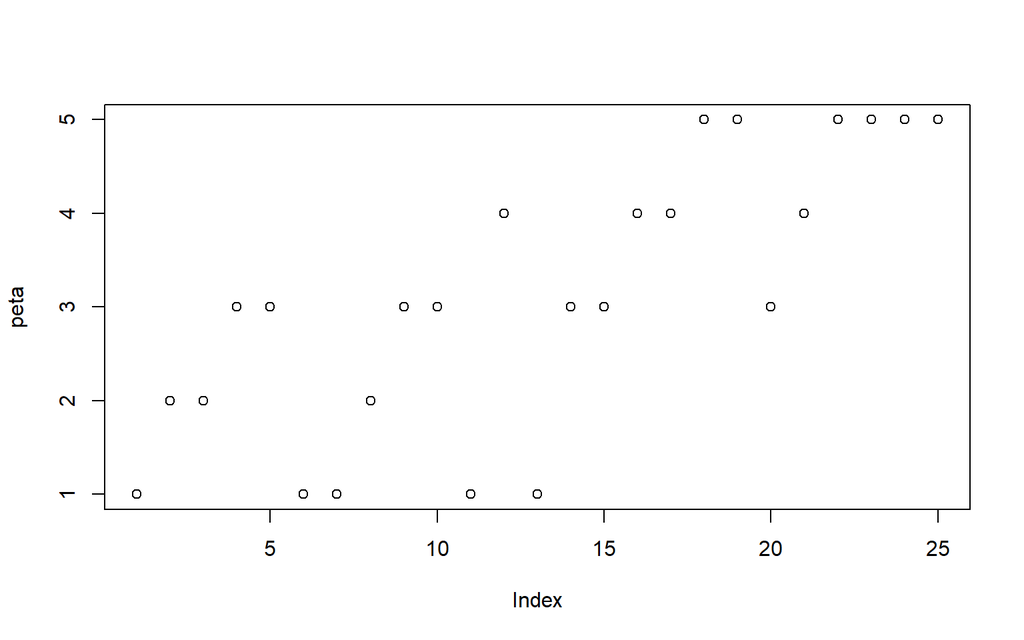

```r
peta <- cutree(hclust(dist(som.wines$codes[[1]])),5)
plot(peta)
```

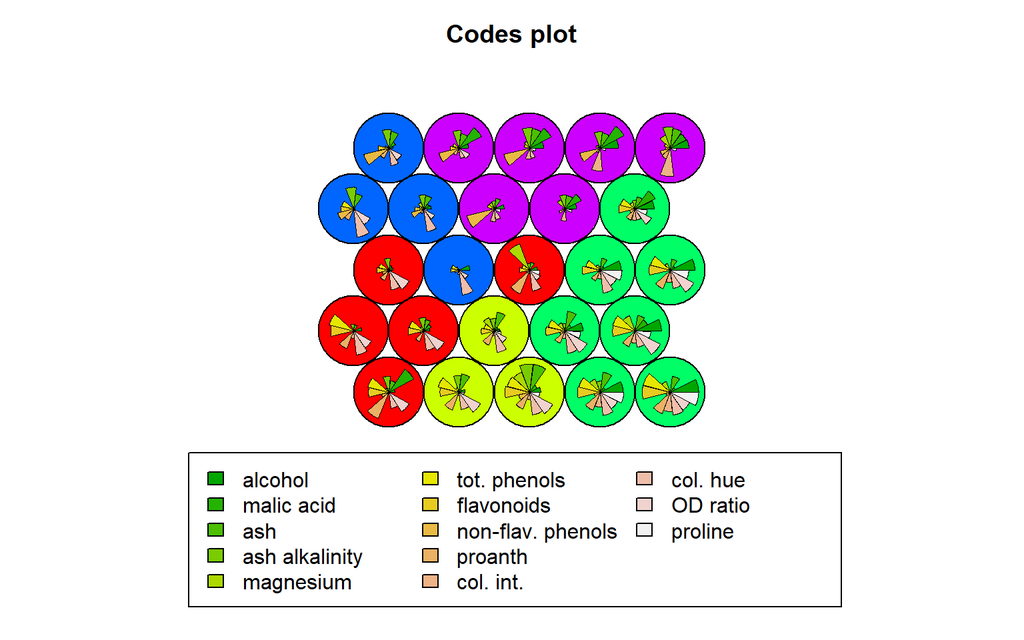

```r
plot(som.wines,type="codes",bgcol=rainbow(5)[peta])
```

# REFRENSI

1. https://medium.com/@16611130/penerapan-self-organizing-map-som-pada-r-menggunakan-data-wines-7c83130fc1a0